# Bivariate analysis

In univariate analysis we only looked at 1 variable (= 1 column) at a time. In bivariate analysis we will now look at the relation between two variables (= 2 columns).

The type of analysis we can do will once again depend on the types of data of these 2 variables. We look look at:

- Numerical VS Numerical.
- Nummerical VS Categorical
- Categorical VS Categorical

## Numerical VS Numerical

Examples:

- Body length VS Shoe size
- Age VS Seconds it takes to run 1 kilometre
- Country Unemployment rate VS Country Happiness Rating
- Customer Revenue VS Customer Lifetime
- Game Wishlists VS Game Purchases
- Student grades VS Student attendance
- ...

```python
import pandas as pd
import seaborn as sns
```

```python
iris = sns.load_dataset("iris")
```

```python
iris.head()
```

|  | sepal_length | sepal_width | petal_length | petal_width | species |
| --- | --- | --- | --- | --- | --- |
| 0 | 5.1 | 3.5 | 1.4 | 0.2 | setosa |
| 1 | 4.9 | 3.0 | 1.4 | 0.2 | setosa |
| 2 | 4.7 | 3.2 | 1.3 | 0.2 | setosa |
| 3 | 4.6 | 3.1 | 1.5 | 0.2 | setosa |
| 4 | 5.0 | 3.6 | 1.4 | 0.2 | setosa |

[figure not shown]

Let's look at the relation between the sepal length and petal length. (Dutch: Kelkblad en bloemblad)

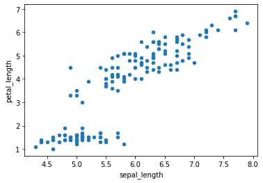

```python
iris.plot(kind='scatter', x='sepal_length', y='petal_length')
```

A useful statistic for calculating the linear relation between two variable is the **Pearson correlation**.  
The Pearson correlation measures the linear relation between two numerical variables. The result is a number between -1 and 1 where

- -1 indicates a perfect negative linear relation
- 0 indicates that there is no linear relation
- 1 indicates a perfect positive linear relation

[figure not shown]

```python
iris[['sepal_length','petal_length']].corr()
```

|  | sepal_length | petal_length |
| --- | --- | --- |
| sepal_length | 1.000000 | 0.871754 |
| petal_length | 0.871754 | 1.000000 |

```python
iris.corr()
```

|  | sepal_length | sepal_width | petal_length | petal_width |
| --- | --- | --- | --- | --- |
| sepal_length | 1.000000 | -0.117570 | 0.871754 | 0.817941 |
| sepal_width | -0.117570 | 1.000000 | -0.428440 | -0.366126 |
| petal_length | 0.871754 | -0.428440 | 1.000000 | 0.962865 |
| petal_width | 0.817941 | -0.366126 | 0.962865 | 1.000000 |

```python
irisCorrelations = iris.corr()
irisCorrelations.style.background_gradient(cmap='coolwarm', axis=None).set_precision(2)
```

|  | sepal_length | sepal_width | petal_length | petal_width |
| --- | --- | --- | --- | --- |
| sepal_length | 1.00 | -0.12 | 0.87 | 0.82 |
| sepal_width | -0.12 | 1.00 | -0.43 | -0.37 |
| petal_length | 0.87 | -0.43 | 1.00 | 0.96 |
| petal_width | 0.82 | -0.37 | 0.96 | 1.00 |

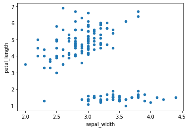

```python
iris.plot(kind='scatter', x='sepal_width', y='petal_length')
```

```python
import numpy as np
```

```python
exampleData = pd.Series(range(100)) + 1
exampleDataNegative = -exampleData
exampleDataDouble = exampleData * 2
exampleDataSquared = exampleData ** 2
exampleDataRoot = exampleData ** 0.5

exampleDataExponential = 2 ** exampleData
exampleDataLog = np.log2(exampleData)

exampleDataWithSmallNoise = exampleData + np.random.randint(low=0, high=10, size=len(exampleData))
exampleDataWithMediumNoise = exampleData + np.random.randint(low=0, high=100, size=len(exampleData))
exampleDataWithHeavyNoise = exampleData + np.random.randint(low=0, high=1000, size=len(exampleData))

exampleDataFrame = pd.DataFrame({'original':exampleData, 'negative':exampleDataNegative, 'double':exampleDataDouble, 'squared':exampleDataSquared, 'root': exampleDataRoot, 'exp':exampleDataExponential, 'log':exampleDataLog, 'noiseSmall': exampleDataWithSmallNoise, 'noiseMedium': exampleDataWithMediumNoise, 'noiseHeavy':exampleDataWithHeavyNoise })
```

```python
exampleDataFrame.head()
```

|  | original | negative | double | squared | root | exp | log | noiseSmall | noiseMedium | noiseHeavy |
| --- | --- | --- | --- | --- | --- | --- | --- | --- | --- | --- |
| 0 | 1 | -1 | 2 | 1 | 1.000000 | 2 | 0.000000 | 5 | 74 | 85 |
| 1 | 2 | -2 | 4 | 4 | 1.414214 | 4 | 1.000000 | 4 | 71 | 781 |
| 2 | 3 | -3 | 6 | 9 | 1.732051 | 8 | 1.584963 | 9 | 51 | 77 |
| 3 | 4 | -4 | 8 | 16 | 2.000000 | 16 | 2.000000 | 7 | 85 | 411 |
| 4 | 5 | -5 | 10 | 25 | 2.236068 | 32 | 2.321928 | 11 | 31 | 129 |

```python
exampleDataCorrelations = exampleDataFrame.corr()
exampleDataCorrelations.style.background_gradient(cmap='coolwarm', axis=None).set_precision(2)
```

|  | original | negative | double | squared | root | exp | log | noiseSmall | noiseMedium | noiseHeavy |
| --- | --- | --- | --- | --- | --- | --- | --- | --- | --- | --- |
| original | 1.00 | -1.00 | 1.00 | 0.97 | 0.98 | -0.01 | 0.90 | 1.00 | 0.65 | 0.12 |
| negative | -1.00 | 1.00 | -1.00 | -0.97 | -0.98 | 0.01 | -0.90 | -1.00 | -0.65 | -0.12 |
| double | 1.00 | -1.00 | 1.00 | 0.97 | 0.98 | -0.01 | 0.90 | 1.00 | 0.65 | 0.12 |
| squared | 0.97 | -0.97 | 0.97 | 1.00 | 0.91 | -0.01 | 0.78 | 0.96 | 0.64 | 0.07 |
| root | 0.98 | -0.98 | 0.98 | 0.91 | 1.00 | -0.00 | 0.96 | 0.98 | 0.62 | 0.16 |
| exp | -0.01 | 0.01 | -0.01 | -0.01 | -0.00 | 1.00 | -0.00 | 0.00 | 0.02 | 0.11 |
| log | 0.90 | -0.90 | 0.90 | 0.78 | 0.96 | -0.00 | 1.00 | 0.89 | 0.55 | 0.19 |
| noiseSmall | 1.00 | -1.00 | 1.00 | 0.96 | 0.98 | 0.00 | 0.89 | 1.00 | 0.64 | 0.12 |
| noiseMedium | 0.65 | -0.65 | 0.65 | 0.64 | 0.62 | 0.02 | 0.55 | 0.64 | 1.00 | 0.02 |
| noiseHeavy | 0.12 | -0.12 | 0.12 | 0.07 | 0.16 | 0.11 | 0.19 | 0.12 | 0.02 | 1.00 |

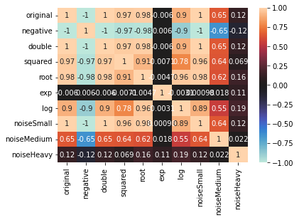

```python
sns.heatmap(exampleDataFrame.corr(), annot = True, vmin=-1, vmax=1, center= 0)
```

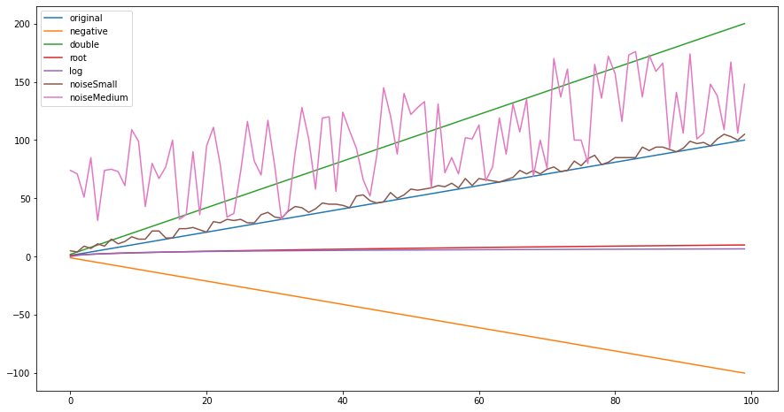

```python
# Excluding a couple of columns because their values are too high to show in the same plot
exampleDataFrame.drop(['exp', 'squared' , 'noiseHeavy'], axis=1).plot(figsize=(15,8))
```

### Portfolio assignment 9

25 min: Perform a bivariate analysis on the columns with numerical data in the penguins dataset.

- Use corr() on the DataFrame to calculate all the correlations. Use the code example above to show the correlation table with colors.
- Look at the corrrelations. Do they match your expectations?
- Show a scatter plot for
  - The strongest positive correlation
  - The strongest negative correlation
  - The weakest correlation

[figure not shown]

```python
penguins = sns.load_dataset("penguins")
```

```python
penguins.head()
```

|  | species | island | bill_length_mm | bill_depth_mm | flipper_length_mm | body_mass_g | sex |
| --- | --- | --- | --- | --- | --- | --- | --- |
| 0 | Adelie | Torgersen | 39.1 | 18.7 | 181.0 | 3750.0 | Male |
| 1 | Adelie | Torgersen | 39.5 | 17.4 | 186.0 | 3800.0 | Female |
| 2 | Adelie | Torgersen | 40.3 | 18.0 | 195.0 | 3250.0 | Female |
| 3 | Adelie | Torgersen | NaN | NaN | NaN | NaN | NaN |
| 4 | Adelie | Torgersen | 36.7 | 19.3 | 193.0 | 3450.0 | Female |

#### Correlation overview

```python
penguins.corr().style.background_gradient(cmap='coolwarm', axis=None).set_precision(2)
```

|  | bill_length_mm | bill_depth_mm | flipper_length_mm | body_mass_g |
| --- | --- | --- | --- | --- |
| bill_length_mm | 1.00 | -0.24 | 0.66 | 0.60 |
| bill_depth_mm | -0.24 | 1.00 | -0.58 | -0.47 |
| flipper_length_mm | 0.66 | -0.58 | 1.00 | 0.87 |
| body_mass_g | 0.60 | -0.47 | 0.87 | 1.00 |

#### Scatter of strongest positive correlation

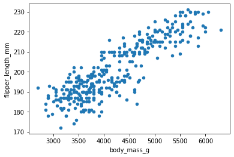

```python
penguins.plot(kind='scatter', x='body_mass_g', y='flipper_length_mm')
```

#### Scatter of strongest negative correlation

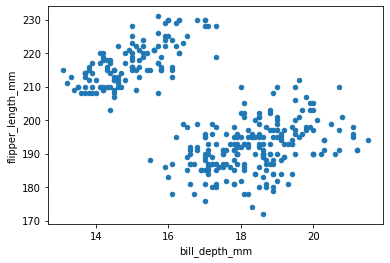

```python
penguins.plot(kind='scatter', x='bill_depth_mm', y='flipper_length_mm')
```

#### Weakest correlation

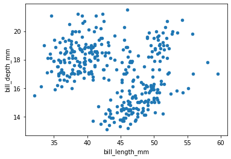

```python
penguins.plot(kind='scatter', x='bill_length_mm', y='bill_depth_mm')
```

### Portfolio assignment 10

15 min: Perform a bivariate analysis (Pearson correlation and scatter plot) on at least 1 combination of 2 columns with numeric data in the dataset that you chose in portfolio assignment 4. Does the correlation and scatter plot match your expectations? Add your answer to your notebook. Commit the Notebook to your portfolio when you're finished.

[figure not shown]

#### Bivariate analysis of runtime to rating

```python
imdb = pd.read_csv('..\imdb-data-2006-2016\IMDB-Movie-Data.csv')
imdb.head()
```

|  | Rank | Title | Genre | Description | Director | Actors | Year | Runtime (Minutes) | Rating | Votes | Revenue (Millions) | Metascore |
| --- | --- | --- | --- | --- | --- | --- | --- | --- | --- | --- | --- | --- |
| 0 | 1 | Guardians of the Galaxy | Action,Adventure,Sci-Fi | A group of intergalactic criminals are forced ... | James Gunn | Chris Pratt, Vin Diesel, Bradley Cooper, Zoe S... | 2014 | 121 | 8.1 | 757074 | 333.13 | 76.0 |
| 1 | 2 | Prometheus | Adventure,Mystery,Sci-Fi | Following clues to the origin of mankind, a te... | Ridley Scott | Noomi Rapace, Logan Marshall-Green, Michael Fa... | 2012 | 124 | 7.0 | 485820 | 126.46 | 65.0 |
| 2 | 3 | Split | Horror,Thriller | Three girls are kidnapped by a man with a diag... | M. Night Shyamalan | James McAvoy, Anya Taylor-Joy, Haley Lu Richar... | 2016 | 117 | 7.3 | 157606 | 138.12 | 62.0 |
| 3 | 4 | Sing | Animation,Comedy,Family | In a city of humanoid animals, a hustling thea... | Christophe Lourdelet | Matthew McConaughey,Reese Witherspoon, Seth Ma... | 2016 | 108 | 7.2 | 60545 | 270.32 | 59.0 |
| 4 | 5 | Suicide Squad | Action,Adventure,Fantasy | A secret government agency recruits some of th... | David Ayer | Will Smith, Jared Leto, Margot Robbie, Viola D... | 2016 | 123 | 6.2 | 393727 | 325.02 | 40.0 |

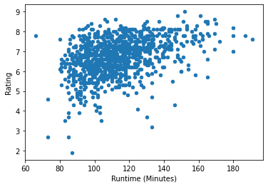

```python
imdb.plot(kind='scatter', y='Rating', x='Runtime (Minutes)')
```

## Numerical VS Categorical

Examples:

- Monthly earnings VS Highest obtained degree
- Body length VS Country of origin
- Happiness rating VS Country of origin
- Sales VS Account Manager.
- Revenue VS Product Category
- Revenue VS Game genre
- Retention VS Software version
- ...

In univariate analysis for numerical data we've looked at confidence intervals. We can use these to check if there are any signicant differences between categories.

You and I are are going to roll a 6-sided die. The numerical variable is the value we roll and the categorical variable is who rolled it. We know that in reality the average value of a 6-sided die is 3.5 (=(1+2+3+4+5+6)/6). We know that there is no skill involved, so who rolls the die should have no impact on the result. We each roll the die 3 times.

[figure not shown]

```python
diceRolls = pd.DataFrame(data= {'Person': ['you', 'you', 'you', 'me','me','me'], 'Rolls': [6,3,6,2,4,2]})
diceRolls
```

|  | Person | Rolls |
| --- | --- | --- |
| 0 | you | 6 |
| 1 | you | 3 |
| 2 | you | 6 |
| 3 | me | 2 |
| 4 | me | 4 |
| 5 | me | 2 |

```python
diceRolls.groupby(by="Person").mean()
```

| Person | Rolls |
| --- | --- |
| me | 2.666667 |
| you | 5.000000 |

Looks like you rolled an average value of 5 and I rolled an average value of ~2.7. Does this mean you are better at rolling dice than me?

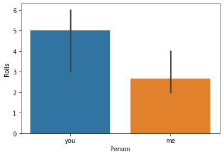

```python
sns.barplot(x="Person", y="Rolls", data=diceRolls)
```

The confidence intervals overlap. This means that we can not yet be sure that you're a better dice roller than me. If we want the confidence intervals to become smaller, we'll need more data which means we need to do more dice rolls.

Let's look if there are significant difference between iris species.

```python
iris.head()
```

|  | sepal_length | sepal_width | petal_length | petal_width | species |
| --- | --- | --- | --- | --- | --- |
| 0 | 5.1 | 3.5 | 1.4 | 0.2 | setosa |
| 1 | 4.9 | 3.0 | 1.4 | 0.2 | setosa |
| 2 | 4.7 | 3.2 | 1.3 | 0.2 | setosa |
| 3 | 4.6 | 3.1 | 1.5 | 0.2 | setosa |
| 4 | 5.0 | 3.6 | 1.4 | 0.2 | setosa |

```python
iris.groupby('species').mean()
```

| species | sepal_length | sepal_width | petal_length | petal_width |
| --- | --- | --- | --- | --- |
| setosa | 5.006 | 3.428 | 1.462 | 0.246 |
| versicolor | 5.936 | 2.770 | 4.260 | 1.326 |
| virginica | 6.588 | 2.974 | 5.552 | 2.026 |

```python
numericalColumnToCheck = "sepal"
```

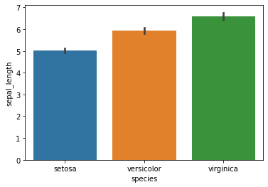

```python
sns.barplot(y="sepal_length", x="species", data=iris)
# Add parameter ci if you want to change certainty of confidence interval.
# For example ci = 99 for 99% certainty.
# The default is 95%
```

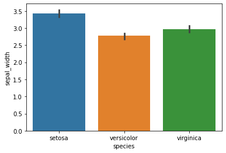

```python
sns.barplot(y="sepal_width", x="species", data=iris)
```

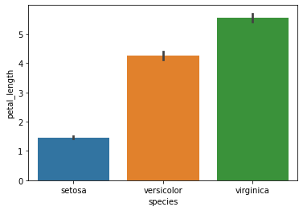

```python
sns.barplot(y="petal_length", x="species", data=iris)
```

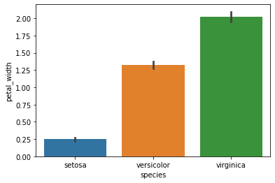

```python
sns.barplot(y="petal_width", x="species", data=iris)
```

### Portfolio assignment 11

20 min: Do a Numerical VS Categorical bivariate analysis on the penguins dataset.

- Choose one of the categorical columns: species, island or sex
- use .groupby('').mean() too look at the means of the numerical columns. Does it look like there is a difference between categories?
- Use the seaborn barplot to plot the mean and confidence. Create this plot for each of the numerical columns (bill_length_mm bill_depth_mm, flipper_length_mm, body_mass_g)
- For each of the plots, write a conclusion: Is there a statistically significant difference for this numerical column for each category?
- Optional: Repeat this proces for the other two categorical columns

```python
penguins.head()
```

|  | species | island | bill_length_mm | bill_depth_mm | flipper_length_mm | body_mass_g | sex |
| --- | --- | --- | --- | --- | --- | --- | --- |
| 0 | Adelie | Torgersen | 39.1 | 18.7 | 181.0 | 3750.0 | Male |
| 1 | Adelie | Torgersen | 39.5 | 17.4 | 186.0 | 3800.0 | Female |
| 2 | Adelie | Torgersen | 40.3 | 18.0 | 195.0 | 3250.0 | Female |
| 3 | Adelie | Torgersen | NaN | NaN | NaN | NaN | NaN |
| 4 | Adelie | Torgersen | 36.7 | 19.3 | 193.0 | 3450.0 | Female |

[figure not shown]

#### Variations in numerical data means by species

- species Adelie: minor deviation in bill length
- species Gentoo: minor deviation in bill length and bill depth ahd flipper length, major deviation in body mass

```python
penguins.groupby('species').mean()
```

| species | bill_length_mm | bill_depth_mm | flipper_length_mm | body_mass_g |
| --- | --- | --- | --- | --- |
| Adelie | 38.791391 | 18.346358 | 189.953642 | 3700.662252 |
| Chinstrap | 48.833824 | 18.420588 | 195.823529 | 3733.088235 |
| Gentoo | 47.504878 | 14.982114 | 217.186992 | 5076.016260 |

##### Other categories

```python
penguins.groupby('island').mean()
```

| island | bill_length_mm | bill_depth_mm | flipper_length_mm | body_mass_g |
| --- | --- | --- | --- | --- |
| Biscoe | 45.257485 | 15.874850 | 209.706587 | 4716.017964 |
| Dream | 44.167742 | 18.344355 | 193.072581 | 3712.903226 |
| Torgersen | 38.950980 | 18.429412 | 191.196078 | 3706.372549 |

```python
penguins.groupby('sex').mean()
```

| sex | bill_length_mm | bill_depth_mm | flipper_length_mm | body_mass_g |
| --- | --- | --- | --- | --- |
| Female | 42.096970 | 16.425455 | 197.363636 | 3862.272727 |
| Male | 45.854762 | 17.891071 | 204.505952 | 4545.684524 |

#### Bill length analysis

The chinstrap and gentoo species share overlapping intervals, while the adelie species' interval does not overlap with any of the other 2 and shows a significantly lower bill length

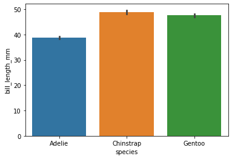

```python
sns.barplot(x='species', y='bill_length_mm', data=penguins)
```

#### Bill depth analysis

The adelie and chinstrap species' intervals are virtually identical, while the gentoo's interval falls well outside of the other's

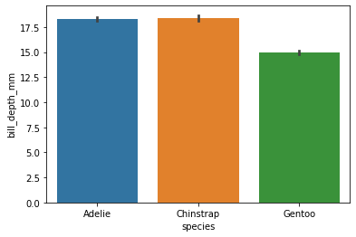

```python
sns.barplot(x='species', y='bill_depth_mm', data=penguins)
```

#### Flipper length analysis

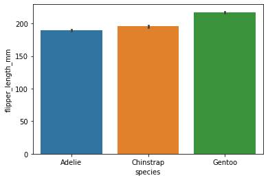

```python
sns.barplot(x='species', y='flipper_length_mm', data=penguins)
```

#### Body mass analysis

the adelie and chinstrap species' body mass appears to be nearly identical, the Gentoo species however has an interval that far beyond the range of the other 2 with a significantly higher body mass

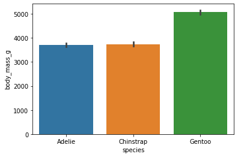

```python
sns.barplot(x='species', y='body_mass_g', data=penguins)
```

### Portfolio assignment 12

30 min: Perform a bivariate analysis on at least 3 combinations of a numerical column with a categorical column in the dataset that you chose in portfolio assignment 4. Use *.groupby('columnname').mean()* to calculate the means. Is there a difference between categories? Then use seaborn barplots to check if there is a statistically significant difference.

[figure not shown]

#### Analysis of mean

significant deviation from the mean can be seen for Rank in 2016, Revenue in 2016 and Metascore in 2006 and 2007

```python
imdb.groupby('Year').mean().style.background_gradient(cmap='coolwarm').set_precision(2)
```

| Year | Rank | Runtime (Minutes) | Rating | Votes | Revenue (Millions) | Metascore |
| --- | --- | --- | --- | --- | --- | --- |
| 2006 | 588.50 | 120.84 | 7.12 | 269289.95 | 86.30 | 64.41 |
| 2007 | 576.58 | 121.62 | 7.13 | 244331.04 | 87.88 | 64.50 |
| 2008 | 625.63 | 110.83 | 6.78 | 275505.38 | 99.08 | 57.41 |
| 2009 | 586.82 | 116.12 | 6.96 | 255780.65 | 112.60 | 57.12 |
| 2010 | 587.32 | 111.13 | 6.83 | 252782.32 | 105.08 | 59.39 |
| 2011 | 589.57 | 114.60 | 6.84 | 240790.30 | 87.61 | 61.72 |
| 2012 | 532.88 | 119.11 | 6.92 | 285226.09 | 107.97 | 61.15 |
| 2013 | 556.23 | 116.07 | 6.81 | 219049.65 | 87.12 | 58.53 |
| 2014 | 512.98 | 114.49 | 6.84 | 203930.22 | 85.08 | 57.32 |
| 2015 | 491.39 | 114.50 | 6.60 | 115726.22 | 78.36 | 57.04 |
| 2016 | 376.44 | 107.37 | 6.44 | 48591.75 | 54.69 | 58.28 |

```python
imdb.mean()
```

```
Rank                     500.500000
Year                    2012.783000
Runtime (Minutes)        113.172000
Rating                     6.723200
Votes                 169808.255000
Revenue (Millions)        82.956376
Metascore                 58.985043
dtype: float64
```

##### Rank analysis

The rank interval in 2016 does not overlap with the intervals of any other year, therefore the anomaly in 2016 is statistically significant

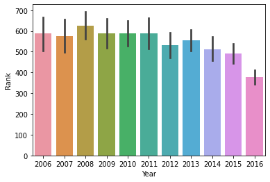

```python
sns.barplot(x='Year', y='Rank', data=imdb)
```

#### Revenue analysis

The interval for 2016's revenie has noticable overlap with various other years (e.g. 2006, 2007, 2015) and is not a statistically significant difference

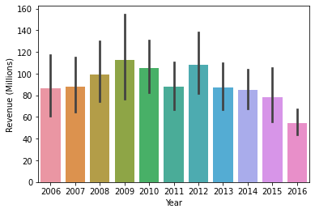

```python
sns.barplot(x='Year', y='Revenue (Millions)', data=imdb)
```

##### Metascore analysis

2006 and 2007's Metascore intervals overlap with many other years and are not statistically significant

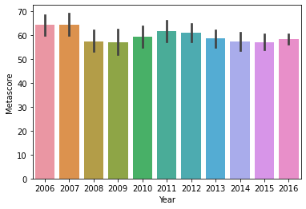

```python
sns.barplot(x='Year', y='Metascore', data=imdb)
```

## Categorical VS Categorical

Examples:

- Inbound channel VS Type of customer
- Education VS Job function
- Region of citizen VS Who the citizen votes for
- Color shirt of crew member in Stat Trek VS Does the crew member survive? (https://statisticsbyjim.com/hypothesis-testing/chi-square-test-independence-example/)
- Customer newsletter subscription (Yes/No) VS Custom churn (Yes/No)
- Penguin island VS Penguin species
- ...

```python
penguins.head()
```

|  | species | island | bill_length_mm | bill_depth_mm | flipper_length_mm | body_mass_g | sex |
| --- | --- | --- | --- | --- | --- | --- | --- |
| 0 | Adelie | Torgersen | 39.1 | 18.7 | 181.0 | 3750.0 | Male |
| 1 | Adelie | Torgersen | 39.5 | 17.4 | 186.0 | 3800.0 | Female |
| 2 | Adelie | Torgersen | 40.3 | 18.0 | 195.0 | 3250.0 | Female |
| 3 | Adelie | Torgersen | NaN | NaN | NaN | NaN | NaN |
| 4 | Adelie | Torgersen | 36.7 | 19.3 | 193.0 | 3450.0 | Female |

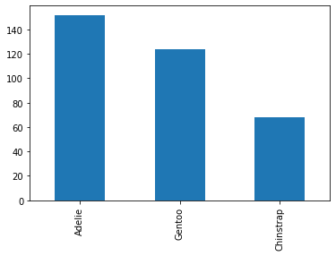

```python
penguins.species.value_counts().plot(kind='bar')
```

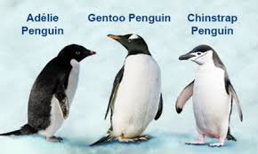

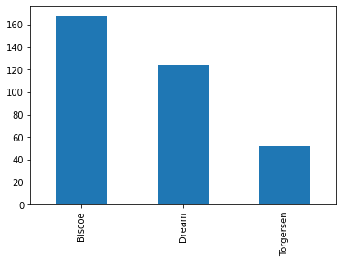

```python
penguins.island.value_counts().plot(kind='bar')
```

```python
contingencyTable = penguins.groupby(['species','island']).size().unstack('species', fill_value=0)
contingencyTable
```

| species island | Adelie | Chinstrap | Gentoo |
| --- | --- | --- | --- |
| Biscoe | 44 | 0 | 124 |
| Dream | 56 | 68 | 0 |
| Torgersen | 52 | 0 | 0 |

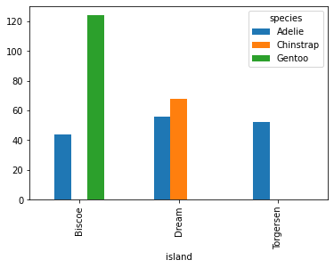

```python
contingencyTable.plot(kind='bar')
```

```python
from scipy.stats import chi2_contingency
chi2_contingency(contingencyTable)
```

```
(299.55032743148195,
 1.3545738297192517e-63,
 4,
 array([[74.23255814, 33.20930233, 60.55813953],
        [54.79069767, 24.51162791, 44.69767442],
        [22.97674419, 10.27906977, 18.74418605]]))
```

```python
diceRolls
```

|  | Person | Rolls |
| --- | --- | --- |
| 0 | you | 6 |
| 1 | you | 3 |
| 2 | you | 6 |
| 3 | me | 2 |
| 4 | me | 4 |
| 5 | me | 2 |

```python
contingencyTableDiceRolls = diceRolls.groupby(['Person','Rolls']).size().unstack('Person', fill_value=0)
contingencyTableDiceRolls
```

| Person Rolls | me | you |
| --- | --- | --- |
| 2 | 2 | 0 |
| 3 | 0 | 1 |
| 4 | 1 | 0 |
| 6 | 0 | 2 |

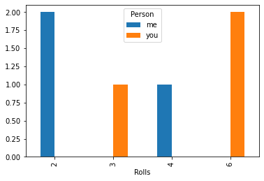

```python
contingencyTableDiceRolls.plot(kind='bar')
```

```python
chi2_contingency(contingencyTableDiceRolls)
```

```
(6.0,
 0.11161022509471268,
 3,
 array([[1. , 1. ],
        [0.5, 0.5],
        [0.5, 0.5],
        [1. , 1. ]]))
```

[figure not shown]

```python
# Change the numberOfRolls and low & high of each player to see the impact on the chi-square test.
numberOfRolls = 5
person1Rolls= pd.Series( np.random.randint(low=1, high=6 + 1, size=numberOfRolls) )
person2Rolls= pd.Series( np.random.randint(low=5, high=6 + 1, size=numberOfRolls) )
diceRolls2 = pd.DataFrame({
    'Person':pd.concat([pd.Series(['Person1']*numberOfRolls),pd.Series(['Person2']*numberOfRolls)]),
    'Rolls':pd.concat([person1Rolls,person2Rolls])
})
diceRolls2.head()
```

|  | Person | Rolls |
| --- | --- | --- |
| 0 | Person1 | 5 |
| 1 | Person1 | 4 |
| 2 | Person1 | 4 |
| 3 | Person1 | 6 |
| 4 | Person1 | 2 |

```python
contingencyTableDiceRolls2 = diceRolls2.groupby(['Person','Rolls']).size().unstack('Person', fill_value=0)
contingencyTableDiceRolls2
```

| Person Rolls | Person1 | Person2 |
| --- | --- | --- |
| 2 | 1 | 0 |
| 4 | 2 | 0 |
| 5 | 1 | 2 |
| 6 | 1 | 3 |

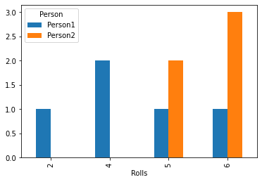

```python
contingencyTableDiceRolls2.plot(kind='bar')
```

```python
chi2_contingency(contingencyTableDiceRolls2)
```

```
(4.333333333333333,
 0.22764711306130173,
 3,
 array([[0.5, 0.5],
        [1. , 1. ],
        [1.5, 1.5],
        [2. , 2. ]]))
```

### Portfolio assignment 13

10 min: Do a bivariate analysis on the penguins dataset for the following combination of columns:

- species VS sex
- island VS sex

For this bivariate analysis, at least perform the following tasks:

- Do you expect their to be a correlation between the two columns?
- Create a contingency table. Do you observe different ratios between categories here?
- Create a bar plot for this contingency table. Do you observe different ratios between categories here?
- Do a chi-squared test. What does the result say? What's the chance of there being a correlation between the two columns?

[figure not shown]

#### Comparison of Island/Species to Sex

Hypothesis: The distribution of male to female penguins should always approximate 1:1, so there should be no significant difference in the ratios shown in the barplots

Because we expect ther eto be no correlation, the chi2 test should result in values close to 1

```python
ctable = penguins.groupby(['species','sex']).size().unstack('species', fill_value=0)
ctable
```

| species sex | Adelie | Chinstrap | Gentoo |
| --- | --- | --- | --- |
| Female | 73 | 34 | 58 |
| Male | 73 | 34 | 61 |

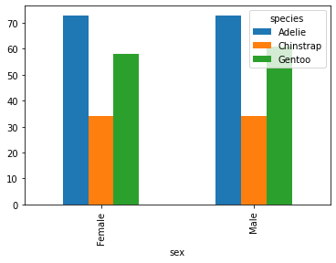

```python
ctable.plot(kind='bar')
```

```python
chi2_contingency(ctable)
```

```
(0.04860717014078319,
 0.9759893689765846,
 2,
 array([[72.34234234, 33.69369369, 58.96396396],
        [73.65765766, 34.30630631, 60.03603604]]))
```

```python
ctable = penguins.groupby(['island','sex']).size().unstack('island', fill_value=0)
ctable
```

| island sex | Biscoe | Dream | Torgersen |
| --- | --- | --- | --- |
| Female | 80 | 61 | 24 |
| Male | 83 | 62 | 23 |

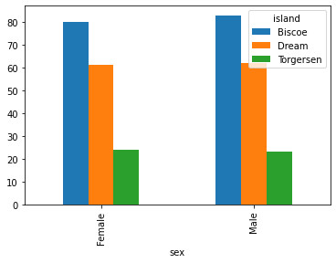

```python
ctable.plot(kind='bar')
```

```python
chi2_contingency(ctable)
```

```
(0.05759904881286206,
 0.971611229281065,
 2,
 array([[80.76576577, 60.94594595, 23.28828829],
        [82.23423423, 62.05405405, 23.71171171]]))
```

### Portfolio assignment 14

Perform a bivariate analysis on at least 1 combination of 2 columns with categorical data in the dataset that you chose in portfolio assignment 4.

- Do you expect their to be a correlation between the two columns?
- Create a contingency table. Do you observe different ratios between categories here?
- Create a bar plot for this contingency table. Do you observe different ratios between categories here?
- Do a chi-squared test. What does the result say? What's the chance of there being a correlation between the two columns?

[figure not shown]

#### Genre vs Year analysis

hyothesis: as trends and interests change over time, so should the ratios between the genres

```
(49.943534806765385, 0.13475142297575715, 40, array([[13.14533623, 12.10412148,  4.38177874,  5.1626898 ,  5.20607375],
       [14.78850325, 13.61713666,  4.92950108,  5.80802603,  5.85683297],
       [17.08893709, 15.73535792,  5.69631236,  6.71149675,  6.76789588],
       [16.76030369, 15.43275488,  5.5867679 ,  6.5824295 ,  6.63774403],
       [21.03253796, 19.36659436,  7.01084599,  8.26030369,  8.329718  ],
       [21.03253796, 19.36659436,  7.01084599,  8.26030369,  8.329718  ],
       [20.37527115, 18.76138829,  6.79175705,  8.0021692 ,  8.06941432],
       [30.23427332, 27.83947939, 10.07809111, 11.87418655, 11.97396963],
       [32.53470716, 29.95770065, 10.84490239, 12.77765727, 12.88503254],
       [35.1637744 , 32.37852495, 11.72125813, 13.81019523, 13.92624729],
       [80.84381779, 74.44034707, 26.94793926, 31.7505423 , 32.01735358]]))
```

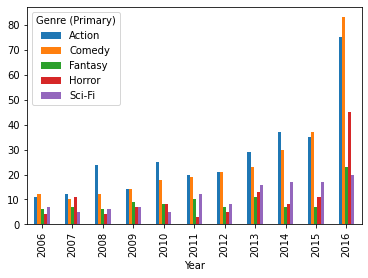

```python
action = imdb[imdb['Genre'].str.contains('Action')]
romance = imdb[imdb['Genre'].str.contains('Sci-Fi')]
horror = imdb[imdb['Genre'].str.contains('Horror')]
comedy = imdb[imdb['Genre'].str.contains('Comedy')]
fantasy = imdb[imdb['Genre'].str.contains('Fantasy')]
action.insert(0, 'Genre (Primary)', 'Action')
romance.insert(0, 'Genre (Primary)', 'Sci-Fi')
horror.insert(0, 'Genre (Primary)', 'Horror')
comedy.insert(0, 'Genre (Primary)', 'Comedy')
fantasy.insert(0, 'Genre (Primary)', 'Fantasy')

imdbSubset = pd.concat([action, romance, horror, comedy, fantasy])

imdbCtable = imdbSubset.groupby(['Genre (Primary)', 'Year']).size().unstack('Genre (Primary)', fill_value=0)
print(chi2_contingency(imdbCtable))
imdbCtable.plot(kind='bar')
```